# ESM 244 Assignment 1 Task 1

Grace Brofman

1/18/2021

```r
library(tidyverse)
library(janitor)
library(lubridate)
```

```r
library(ggfortify)
library(readxl)
library(gghighlight)
library(patchwork)
library(plotly)
library(viridis)
library(RColorBrewer)
```

### Task 1: Sierra Amphibian visualization

Read in excel file:

```r
sierra_amph <- read_excel("sierra_amphibians.xlsx")
```

#### Part !:

A graph of total mountain yellow-legged frog (Rana muscosa) count each year across all water bodies, by life stage excluding the ‘EggMass’ level. In other words, you should find the total number of adult, subadult, and tadpole yellow-legged frogs observed in the entire study region by life stage and year, but you will not use the lake ID or amphibian_location in your analyses as additional grouping variables (thanks Elmera Azadpour for clarifying). Hint: Convert the date to a date with the {lubridate} package, then pull just the year using the lubridate::year() function…then you can group by year to get counts.

```r
# Sort for Rana muscosa (RAMU) and remove "EggMass" life stage

ramu <- sierra_amph %>%
  filter(str_detect(amphibian_species, "RAMU")) %>%
  filter(amphibian_life_stage != "EggMass")

# convert date with lubridate
ramu_date <- ramu %>%
  mutate(date = ymd(survey_date)) %>%
  mutate(survey_year = year(date)) #created a new column called survey_year which holds only the year %

ramu_summary <- ramu_date %>%
 group_by(survey_year, amphibian_life_stage) %>%
  summarize(n_observed = sum(amphibian_number))
```

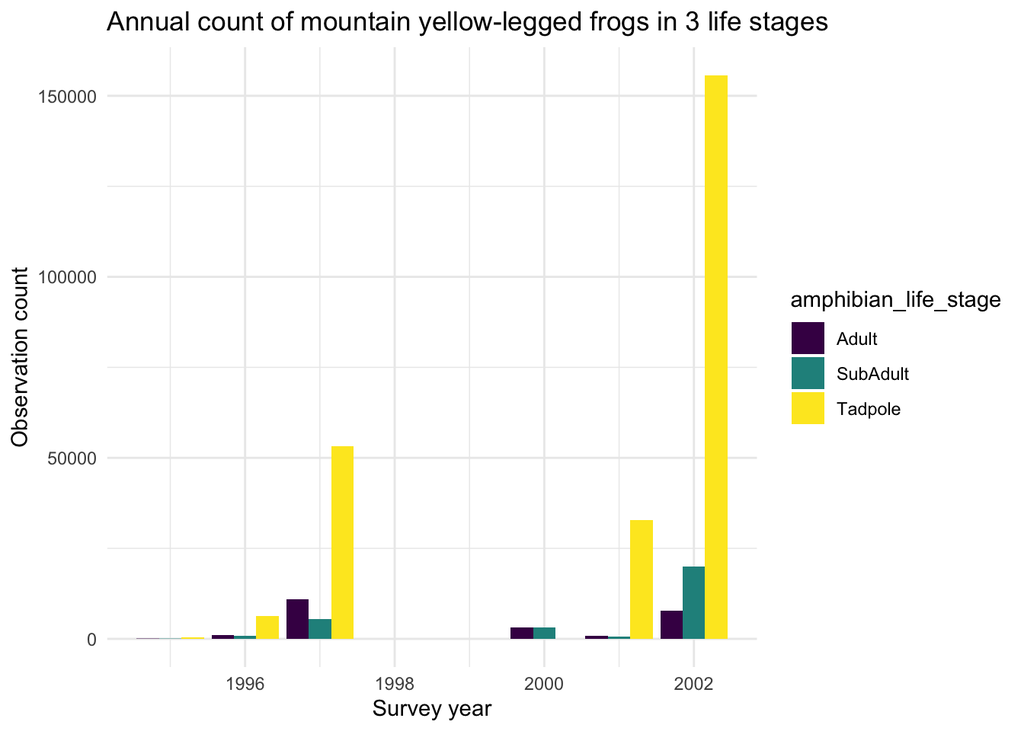

```r
# graph observations
graph_1 <- ggplot(data = ramu_summary,
       aes(x = survey_year,
           y = n_observed,
           fill = amphibian_life_stage)) +
  geom_col(position = "dodge") +
  scale_fill_viridis_d() +
  theme_minimal() +
  labs(x = "Survey year", y = "Observation count", title = "Annual count of mountain yellow-legged frogs in 3 life stages")


graph_1
```

#### Part 2:

A column graph containing total counts (over all years of the study) of combined adult and subadult endangered mountain yellow-legged frogs (Rana muscosa) observed in the 5 lakes with the greatest total observed counts. In other words, this graph will have at least 5 columns (OK to have more if there are ties - thanks Michelle Shteyn), with Lake ID (these aren’t specified in the dataset for confidentiality) as the categorical label on one axis, and total yellow-legged frog counts (adult + subadult counts) in the dataset on the other axis. Make sure they’re in high-to-low or low-to-high order by total yellow-legged frog counts. You should exclude tadpoles for this graph. Note: Consider reformatting the lake ID from just a number to a label like “Lake 10025”), then use fct_reorder to convert it to an ordered factor.

```r
# Remove tadpole from ramu_date dataset
ramu_pt_2 <- ramu_date %>%
  filter(amphibian_life_stage != "Tadpole") %>%
  group_by(lake_id) %>%
  summarize(total_observed = sum(amphibian_number))
```

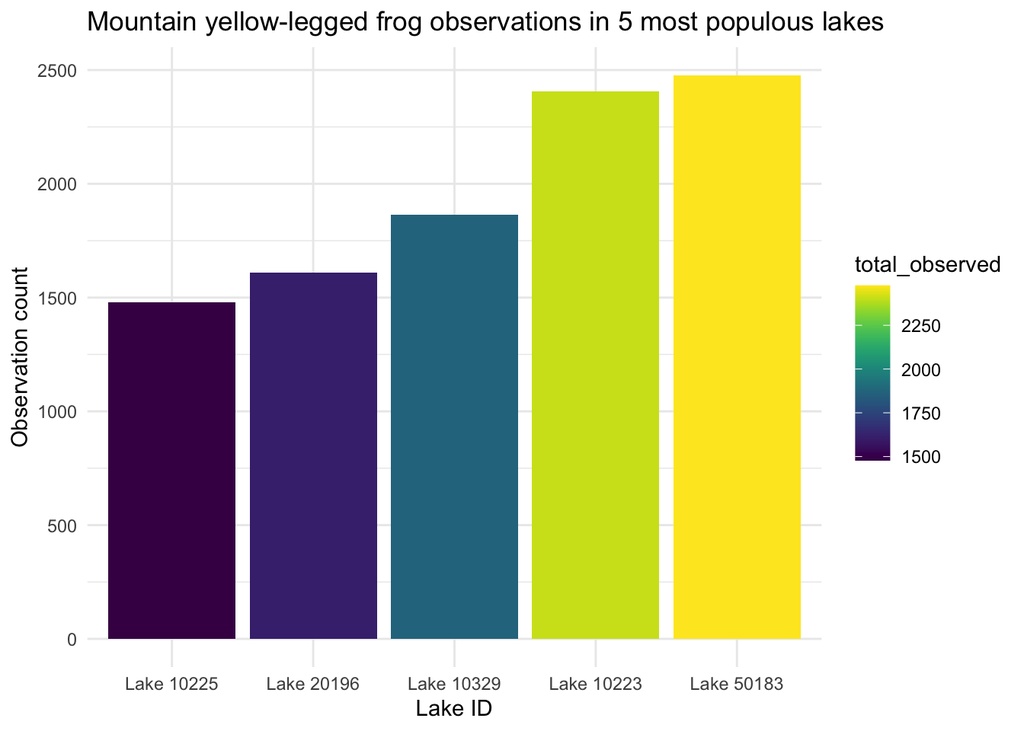

```r
# take only the 5 lakes with the most observations
ramu_5_lakes <- ramu_pt_2 %>%
  slice_max(total_observed, n = 5) %>%
  mutate(lake_id = as.character(lake_id))


# rename lake_id column to add "Lake"
ramu_5_lakes[1,1] <- "Lake 50183"
ramu_5_lakes[2,1] <- "Lake 10223"
ramu_5_lakes[3,1] <- "Lake 10329"
ramu_5_lakes[4,1] <- "Lake 20196"
ramu_5_lakes[5,1] <- "Lake 10225"

graph_2 <- ggplot(data = ramu_5_lakes,
       aes(x = fct_reorder(lake_id, total_observed, min), #to reorder bars in ascending order
           y = total_observed)) +
  geom_col(aes(fill = total_observed)) +
  theme_minimal() +
  labs(x = "Lake ID", y = "Observation count", title = "Mountain yellow-legged frog observations in 5 most populous lakes") +
  scale_fill_viridis(option = "D")

graph_2
```

Combine your two graphs into a single compound figure using the {patchwork} package. Add a finalized figure caption that appears below the compound figure in your knitted html. Note: You might realize once you combine your graphs into a single compound figure, you need to update the formatting (e.g. move legends or instead directly label, etc.). You should customize as necessary to make it a professional final output.

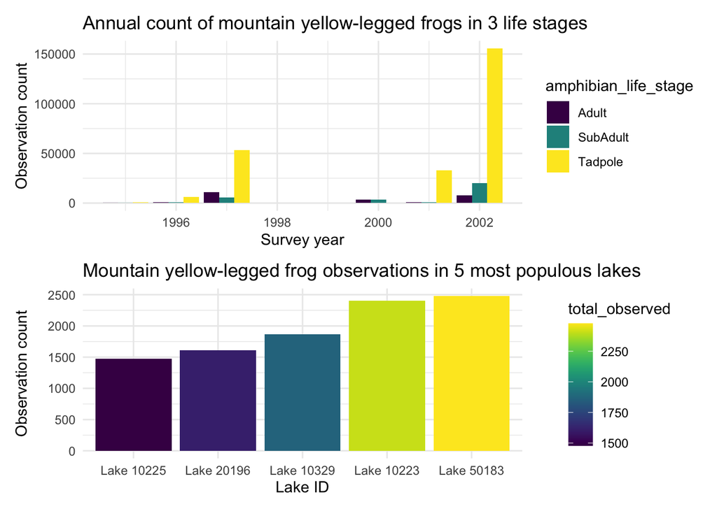

```r
graph_1 / graph_2
```